[figure not shown]

# Grace College Internal COVID-19 Data

## Compiled by Dr. Ryan Johnson using contact tracing data from Laura Green and testing data from the state of Indiana.

### Last updated Wednesday, August 26, 2020, at 10:04AM

# Cases

In the graphs below, confirmed cases are matched to the date the test was taken, not the date of the test result. Thus, **be careful** making inferences based on the most recent 2-4 days, because those numbers might go up as tests come back.

### Confirmed Cases Among Students

Grace College has

- 0 current confirmed cases among students at Grace.
- 0 total confirmed cases among students at Grace.
- 6 current confirmed cases among students at Home.
- 6 total confirmed cases among students at Home.

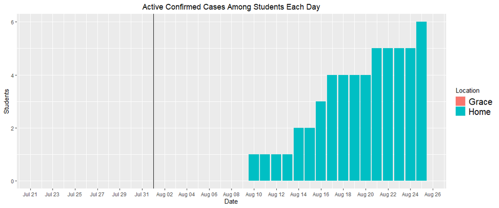

### Confirmed Cases Among Employees

Grace College has

- 2 current confirmed cases among the employees.
- 2 total confirmed cases among the employees.

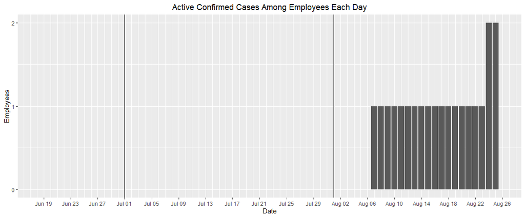

# Isolated

### Isolated Students

Grace College has

- 1 current isolated students at Grace.
- 2 total isolated students at Grace. It theoretically possible for a student to be isolated more than once if they test negative the first time.
- 8 current isolated students at Home.
- 12 total isolated students at Home. It theoretically possible for a student to be isolated more than once if they test negative the first time.

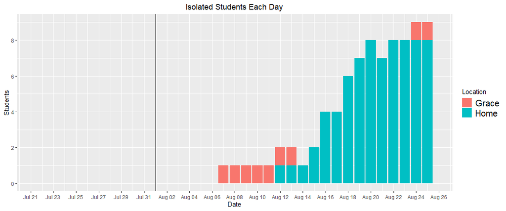

### Isolated Employees

Grace College has

- 4 current isolated employees.
- 10 total isolated employees. It theoretically possible for an employee to be isolated more than once if they test negative the first time.

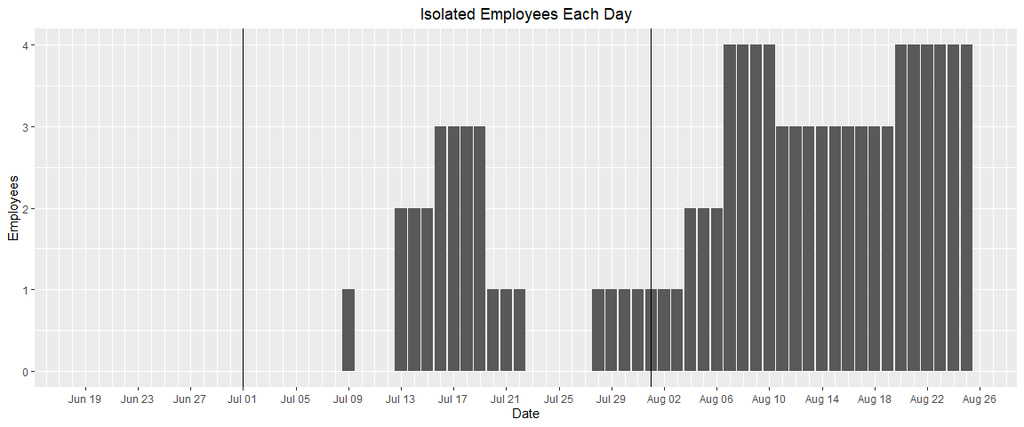

# Quarantined

### Quarantined Students

Grace College has

- 1 current quarantined students at Grace because of exposure.
- 1 total quarantined students at Grace because of exposure. It theoretically possible for a student to be quarantined more than once if they do not show symptoms first time.
- 26 current quarantined students at Home because of exposure.
- 27 total quarantined students at Home because of exposure. It theoretically possible for a student to be quarantined more than once if they do not show symptoms first time.

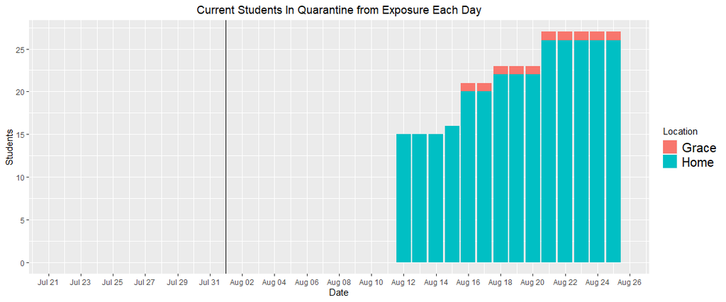

### Quarantined Employees

Grace College has

- 3 current quarantined employees.
- 9 total quarantined employees. It theoretically possible for an employee to be quarantined more than once if they do not show symptoms first time.

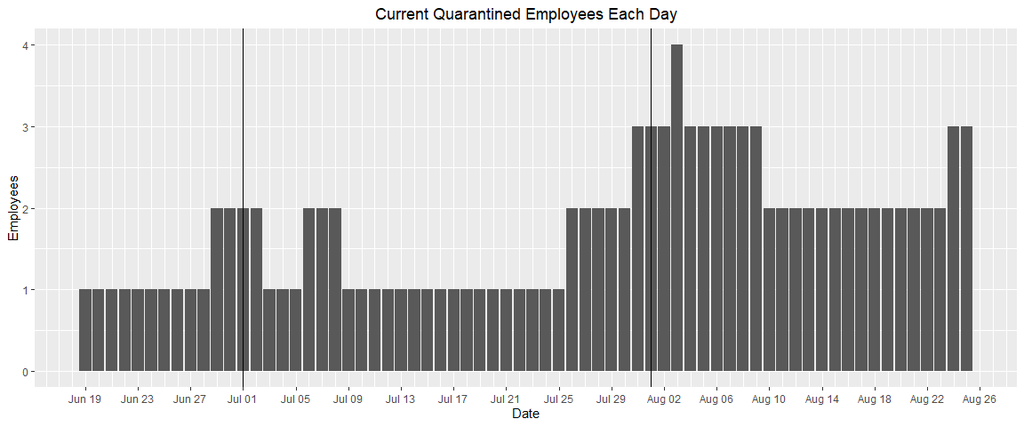

# Kosciusko County

Kosciusko County has had

- 7.7 cases per day the past week.
- 955 total confirmed cases.

### Cases - Kosciusko

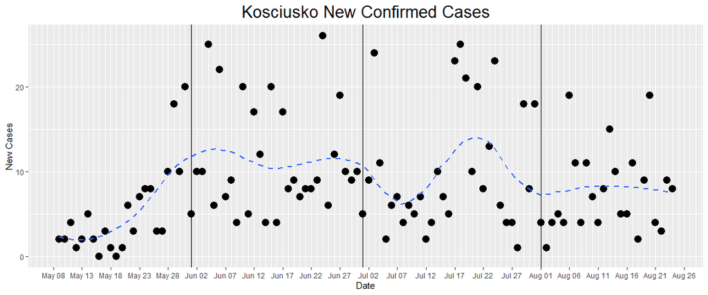

### Positivity - Kosciusko

Kosciusko County has had 15.8% 7-day positivity rate for unique indiviudals as of August 20 according to the Indiana Coronavirus Dashboard.

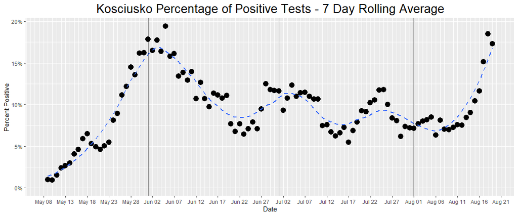

# Indiana

The total case numbers below are multiplied by $\frac{\text{Kos pop}}{\text{Ind pop}} = \frac{79456}{6732000} = 0.01180273$, so that it is easier to compare Kosciusko numbers to the average Indiana county.

Indiana has had

- 864 cases per day the past week (normalized 10.2).
- 64,831 total confirmed cases (normalized 765.2).

### Cases - Indiana

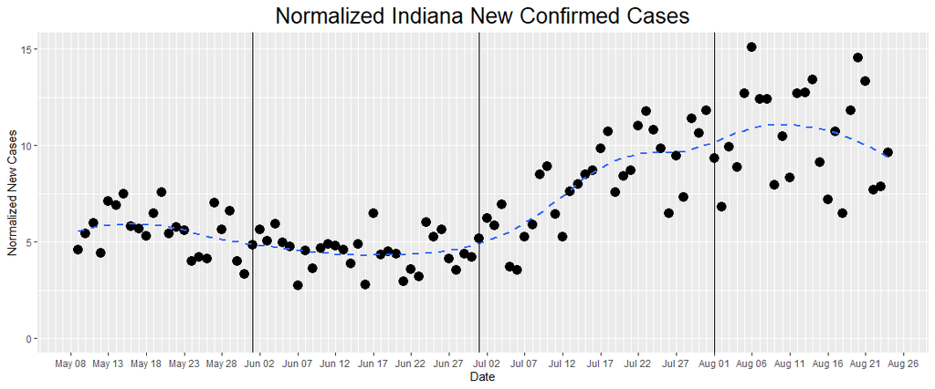

### Positivity - Indiana

Indiana has had 6.8% 7-day positivity rate for unique indiviudals as of August 19 according to the Indiana Coronavirus Dashboard..

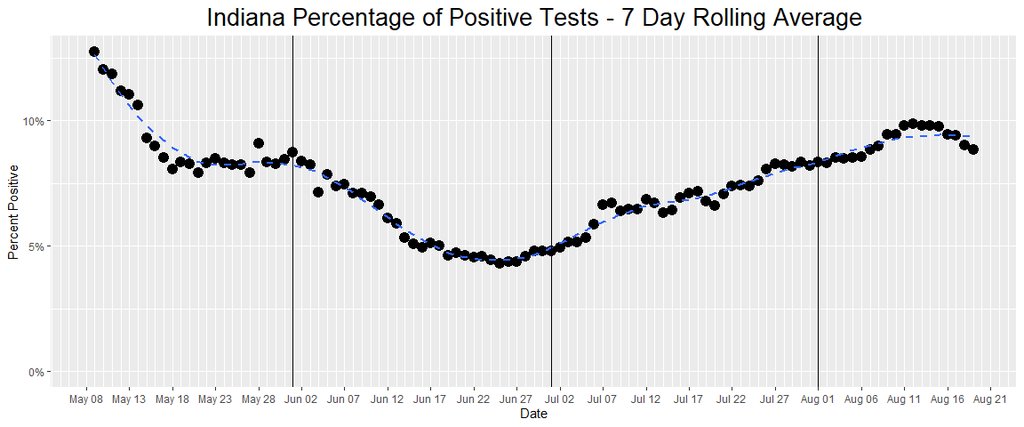